# Risk Factor Analysis

## Outcome Variable

**Outcome Variable:** ever_stunted

## Predictor Variables

**Intervention Variable:** earlybf

**Adjustment Set:**

- arm
- sex
- W_mage
- meducyrs
- feducyrs
- hhwealth_quart
- W_mhtcm
- W_mwtkg
- W_mbmi
- vagbrth
- W_birthwt
- W_birthlen
- W_nrooms
- W_nchldlt5
- brthmon
- W_parity
- impfloor
- impsan
- safeh20
- delta_W_mage
- delta_meducyrs
- delta_feducyrs
- delta_hhwealth_quart
- delta_W_mhtcm
- delta_W_mwtkg
- delta_W_mbmi
- delta_vagbrth
- delta_W_birthwt
- delta_W_birthlen
- delta_W_nrooms
- delta_W_nchldlt5
- delta_brthmon
- delta_W_parity
- delta_impfloor
- delta_impsan
- delta_safeh20

## Stratifying Variables

The analysis was stratified on these variable(s):

- agecat
- studyid
- country

## Data Summary

| agecat | studyid | country | earlybf | ever_stunted | n_cell | n |
| --- | --- | --- | --- | --- | --- | --- |
| 0-24 months (no birth st.) | EE | PAKISTAN | 1 | 0 | 12 | 206 |
| 0-24 months (no birth st.) | EE | PAKISTAN | 1 | 1 | 31 | 206 |
| 0-24 months (no birth st.) | EE | PAKISTAN | 0 | 0 | 26 | 206 |
| 0-24 months (no birth st.) | EE | PAKISTAN | 0 | 1 | 137 | 206 |
| 0-24 months (no birth st.) | GMS-Nepal | NEPAL | 1 | 0 | 77 | 527 |
| 0-24 months (no birth st.) | GMS-Nepal | NEPAL | 1 | 1 | 77 | 527 |
| 0-24 months (no birth st.) | GMS-Nepal | NEPAL | 0 | 0 | 155 | 527 |
| 0-24 months (no birth st.) | GMS-Nepal | NEPAL | 0 | 1 | 218 | 527 |
| 0-24 months (no birth st.) | JiVitA-3 | BANGLADESH | 1 | 0 | 79 | 18308 |
| 0-24 months (no birth st.) | JiVitA-3 | BANGLADESH | 1 | 1 | 17 | 18308 |
| 0-24 months (no birth st.) | JiVitA-3 | BANGLADESH | 0 | 0 | 13594 | 18308 |
| 0-24 months (no birth st.) | JiVitA-3 | BANGLADESH | 0 | 1 | 4618 | 18308 |
| 0-24 months (no birth st.) | JiVitA-4 | BANGLADESH | 1 | 0 | 1421 | 3886 |
| 0-24 months (no birth st.) | JiVitA-4 | BANGLADESH | 1 | 1 | 1056 | 3886 |
| 0-24 months (no birth st.) | JiVitA-4 | BANGLADESH | 0 | 0 | 858 | 3886 |
| 0-24 months (no birth st.) | JiVitA-4 | BANGLADESH | 0 | 1 | 551 | 3886 |
| 0-24 months (no birth st.) | MAL-ED | BANGLADESH | 1 | 0 | 65 | 216 |
| 0-24 months (no birth st.) | MAL-ED | BANGLADESH | 1 | 1 | 73 | 216 |
| 0-24 months (no birth st.) | MAL-ED | BANGLADESH | 0 | 0 | 38 | 216 |
| 0-24 months (no birth st.) | MAL-ED | BANGLADESH | 0 | 1 | 40 | 216 |
| 0-24 months (no birth st.) | MAL-ED | BRAZIL | 1 | 0 | 78 | 202 |
| 0-24 months (no birth st.) | MAL-ED | BRAZIL | 1 | 1 | 17 | 202 |
| 0-24 months (no birth st.) | MAL-ED | BRAZIL | 0 | 0 | 92 | 202 |
| 0-24 months (no birth st.) | MAL-ED | BRAZIL | 0 | 1 | 15 | 202 |
| 0-24 months (no birth st.) | MAL-ED | INDIA | 1 | 0 | 61 | 209 |
| 0-24 months (no birth st.) | MAL-ED | INDIA | 1 | 1 | 66 | 209 |
| 0-24 months (no birth st.) | MAL-ED | INDIA | 0 | 0 | 37 | 209 |
| 0-24 months (no birth st.) | MAL-ED | INDIA | 0 | 1 | 45 | 209 |
| 0-24 months (no birth st.) | MAL-ED | NEPAL | 1 | 0 | 65 | 211 |
| 0-24 months (no birth st.) | MAL-ED | NEPAL | 1 | 1 | 25 | 211 |

[output cut: 82 more lines]

The following strata were considered:

- agecat: 0-24 months (no birth st.), studyid: EE, country: PAKISTAN
- agecat: 0-24 months (no birth st.), studyid: GMS-Nepal, country: NEPAL
- agecat: 0-24 months (no birth st.), studyid: JiVitA-3, country: BANGLADESH
- agecat: 0-24 months (no birth st.), studyid: JiVitA-4, country: BANGLADESH
- agecat: 0-24 months (no birth st.), studyid: MAL-ED, country: BANGLADESH
- agecat: 0-24 months (no birth st.), studyid: MAL-ED, country: BRAZIL
- agecat: 0-24 months (no birth st.), studyid: MAL-ED, country: INDIA
- agecat: 0-24 months (no birth st.), studyid: MAL-ED, country: NEPAL
- agecat: 0-24 months (no birth st.), studyid: MAL-ED, country: PERU
- agecat: 0-24 months (no birth st.), studyid: MAL-ED, country: SOUTH AFRICA
- agecat: 0-24 months (no birth st.), studyid: MAL-ED, country: TANZANIA, UNITED REPUBLIC OF
- agecat: 0-24 months (no birth st.), studyid: NIH-Crypto, country: BANGLADESH
- agecat: 0-24 months (no birth st.), studyid: SAS-CompFeed, country: INDIA
- agecat: 0-24 months (no birth st.), studyid: ZVITAMBO, country: ZIMBABWE
- agecat: 0-6 months (no birth st.), studyid: EE, country: PAKISTAN
- agecat: 0-6 months (no birth st.), studyid: GMS-Nepal, country: NEPAL
- agecat: 0-6 months (no birth st.), studyid: JiVitA-3, country: BANGLADESH
- agecat: 0-6 months (no birth st.), studyid: JiVitA-4, country: BANGLADESH
- agecat: 0-6 months (no birth st.), studyid: MAL-ED, country: BANGLADESH
- agecat: 0-6 months (no birth st.), studyid: MAL-ED, country: BRAZIL
- agecat: 0-6 months (no birth st.), studyid: MAL-ED, country: INDIA
- agecat: 0-6 months (no birth st.), studyid: MAL-ED, country: NEPAL
- agecat: 0-6 months (no birth st.), studyid: MAL-ED, country: PERU
- agecat: 0-6 months (no birth st.), studyid: MAL-ED, country: SOUTH AFRICA
- agecat: 0-6 months (no birth st.), studyid: MAL-ED, country: TANZANIA, UNITED REPUBLIC OF
- agecat: 0-6 months (no birth st.), studyid: NIH-Crypto, country: BANGLADESH
- agecat: 0-6 months (no birth st.), studyid: SAS-CompFeed, country: INDIA
- agecat: 0-6 months (no birth st.), studyid: ZVITAMBO, country: ZIMBABWE

## Methods Detail

We're interested in the causal parameters $E[Y_a]$ for all values of $a \in \mathcal{A}$. These parameters represent the mean outcome if, possibly contrary to fact, we intervened to set all units to have $A=a$. Under the randomization and positivity assumptions, these are identified by the statistical parameters $\psi_a=E_W[E_{Y|A,W}(Y|A=a,W)]$. In addition, we're interested in the mean of $Y$, $E[Y]$ under no intervention (the observed mean). We will estimate these parameters by using SuperLearner to fit the relevant likelihood factors -- $E_{Y|A,W}(Y|A=a,W)$ and $p(A=a|W)$, and then updating our likelihood fit using a joint TMLE.

For unadjusted analyses ($W=\{\}$), initial likelihoods were estimated using Lrnr_glm to estimate the simple $E(Y|A)$ and Lrnr_mean to estimate $p(A)$. For adjusted analyses, a small library containing Lrnr_glmnet, Lrnr_xgboost, and Lrnr_mean was used.

Having estimated these parameters, we will then use the delta method to estimate relative risks and attributable risks relative to a prespecified baseline level of $A$.

# Results Detail

## Results Plots

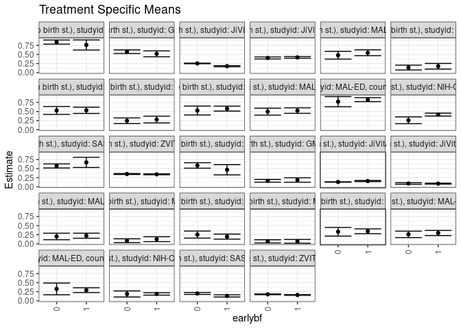

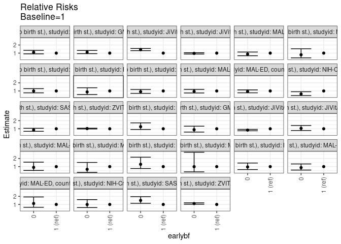

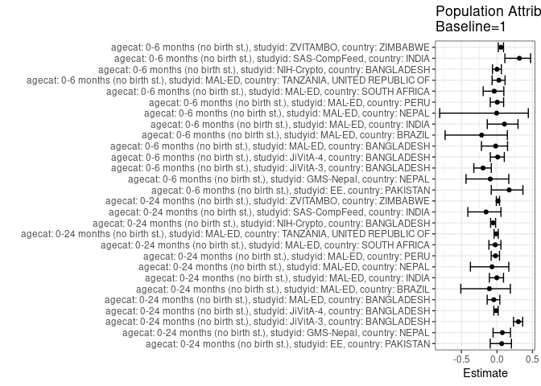

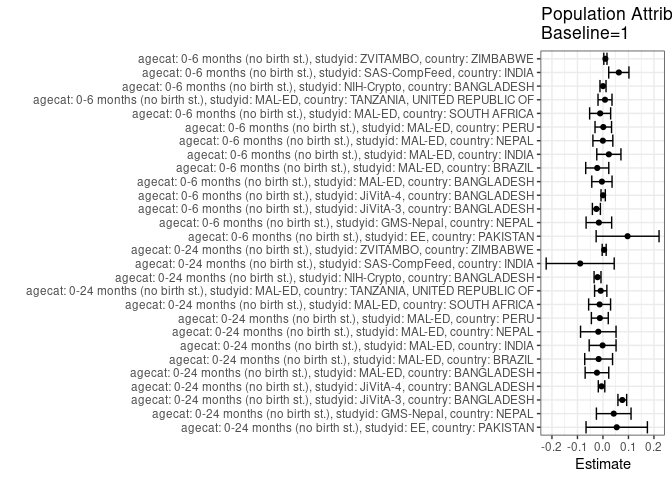

## Results Table

### Parameter: TSM

| agecat | studyid | country | intervention_level | baseline_level | estimate | ci_lower | ci_upper |
| --- | --- | --- | --- | --- | --- | --- | --- |
| 0-24 months (no birth st.) | EE | PAKISTAN | 1 | NA | 0.7615113 | 0.6227191 | 0.9003036 |
| 0-24 months (no birth st.) | EE | PAKISTAN | 0 | NA | 0.8407842 | 0.7840972 | 0.8974712 |
| 0-24 months (no birth st.) | GMS-Nepal | NEPAL | 1 | NA | 0.5175078 | 0.4361948 | 0.5988208 |
| 0-24 months (no birth st.) | GMS-Nepal | NEPAL | 0 | NA | 0.5761345 | 0.5266827 | 0.6255863 |
| 0-24 months (no birth st.) | JiVitA-3 | BANGLADESH | 1 | NA | 0.1772646 | 0.1615890 | 0.1929402 |
| 0-24 months (no birth st.) | JiVitA-3 | BANGLADESH | 0 | NA | 0.2535715 | 0.2456305 | 0.2615125 |
| 0-24 months (no birth st.) | JiVitA-4 | BANGLADESH | 1 | NA | 0.4190388 | 0.3957521 | 0.4423254 |
| 0-24 months (no birth st.) | JiVitA-4 | BANGLADESH | 0 | NA | 0.4037100 | 0.3759943 | 0.4314257 |
| 0-24 months (no birth st.) | MAL-ED | BANGLADESH | 1 | NA | 0.5466864 | 0.4652854 | 0.6280875 |
| 0-24 months (no birth st.) | MAL-ED | BANGLADESH | 0 | NA | 0.4789283 | 0.3725116 | 0.5853450 |
| 0-24 months (no birth st.) | MAL-ED | BRAZIL | 1 | NA | 0.1753149 | 0.0974362 | 0.2531936 |
| 0-24 months (no birth st.) | MAL-ED | BRAZIL | 0 | NA | 0.1396817 | 0.0730481 | 0.2063154 |
| 0-24 months (no birth st.) | MAL-ED | INDIA | 1 | NA | 0.5324128 | 0.4462433 | 0.6185822 |
| 0-24 months (no birth st.) | MAL-ED | INDIA | 0 | NA | 0.5285760 | 0.4206180 | 0.6365339 |
| 0-24 months (no birth st.) | MAL-ED | NEPAL | 1 | NA | 0.2789126 | 0.1860897 | 0.3717354 |
| 0-24 months (no birth st.) | MAL-ED | NEPAL | 0 | NA | 0.2453162 | 0.1673303 | 0.3233020 |
| 0-24 months (no birth st.) | MAL-ED | PERU | 1 | NA | 0.5798898 | 0.5116446 | 0.6481349 |
| 0-24 months (no birth st.) | MAL-ED | PERU | 0 | NA | 0.5280364 | 0.4052489 | 0.6508239 |
| 0-24 months (no birth st.) | MAL-ED | SOUTH AFRICA | 1 | NA | 0.5246614 | 0.4491014 | 0.6002214 |
| 0-24 months (no birth st.) | MAL-ED | SOUTH AFRICA | 0 | NA | 0.4970124 | 0.4020075 | 0.5920173 |
| 0-24 months (no birth st.) | MAL-ED | TANZANIA, UNITED REPUBLIC OF | 1 | NA | 0.8260870 | 0.7711946 | 0.8809793 |
| 0-24 months (no birth st.) | MAL-ED | TANZANIA, UNITED REPUBLIC OF | 0 | NA | 0.7714286 | 0.6319952 | 0.9108619 |
| 0-24 months (no birth st.) | NIH-Crypto | BANGLADESH | 1 | NA | 0.4147866 | 0.3744570 | 0.4551161 |
| 0-24 months (no birth st.) | NIH-Crypto | BANGLADESH | 0 | NA | 0.2585523 | 0.1653183 | 0.3517863 |
| 0-24 months (no birth st.) | SAS-CompFeed | INDIA | 1 | NA | 0.6696556 | 0.5294582 | 0.8098531 |
| 0-24 months (no birth st.) | SAS-CompFeed | INDIA | 0 | NA | 0.5721341 | 0.5160117 | 0.6282564 |
| 0-24 months (no birth st.) | ZVITAMBO | ZIMBABWE | 1 | NA | 0.3417912 | 0.3300632 | 0.3535193 |
| 0-24 months (no birth st.) | ZVITAMBO | ZIMBABWE | 0 | NA | 0.3499593 | 0.3373674 | 0.3625511 |
| 0-6 months (no birth st.) | EE | PAKISTAN | 1 | NA | 0.4664487 | 0.3261618 | 0.6067357 |
| 0-6 months (no birth st.) | EE | PAKISTAN | 0 | NA | 0.5854724 | 0.5105917 | 0.6603530 |
| 0-6 months (no birth st.) | GMS-Nepal | NEPAL | 1 | NA | 0.1848294 | 0.1244765 | 0.2451824 |
| 0-6 months (no birth st.) | GMS-Nepal | NEPAL | 0 | NA | 0.1640405 | 0.1264620 | 0.2016190 |
| 0-6 months (no birth st.) | JiVitA-3 | BANGLADESH | 1 | NA | 0.1564617 | 0.1413728 | 0.1715506 |
| 0-6 months (no birth st.) | JiVitA-3 | BANGLADESH | 0 | NA | 0.1306010 | 0.1248792 | 0.1363227 |
| 0-6 months (no birth st.) | JiVitA-4 | BANGLADESH | 1 | NA | 0.0847017 | 0.0717772 | 0.0976263 |
| 0-6 months (no birth st.) | JiVitA-4 | BANGLADESH | 0 | NA | 0.0888405 | 0.0666881 | 0.1109929 |
| 0-6 months (no birth st.) | MAL-ED | BANGLADESH | 1 | NA | 0.2216502 | 0.1527262 | 0.2905742 |
| 0-6 months (no birth st.) | MAL-ED | BANGLADESH | 0 | NA | 0.2009826 | 0.1113882 | 0.2905770 |
| 0-6 months (no birth st.) | MAL-ED | BRAZIL | 1 | NA | 0.1263158 | 0.0593474 | 0.1932842 |
| 0-6 months (no birth st.) | MAL-ED | BRAZIL | 0 | NA | 0.0841121 | 0.0313911 | 0.1368332 |
| 0-6 months (no birth st.) | MAL-ED | INDIA | 1 | NA | 0.1969091 | 0.1275792 | 0.2662390 |
| 0-6 months (no birth st.) | MAL-ED | INDIA | 0 | NA | 0.2531407 | 0.1565600 | 0.3497214 |
| 0-6 months (no birth st.) | MAL-ED | NEPAL | 1 | NA | 0.0666667 | 0.0150094 | 0.1183239 |
| 0-6 months (no birth st.) | MAL-ED | NEPAL | 0 | NA | 0.0661157 | 0.0217359 | 0.1104956 |
| 0-6 months (no birth st.) | MAL-ED | PERU | 1 | NA | 0.3445152 | 0.2785932 | 0.4104372 |
| 0-6 months (no birth st.) | MAL-ED | PERU | 0 | NA | 0.3304688 | 0.2112791 | 0.4496585 |
| 0-6 months (no birth st.) | MAL-ED | SOUTH AFRICA | 1 | NA | 0.2956544 | 0.2252472 | 0.3660616 |
| 0-6 months (no birth st.) | MAL-ED | SOUTH AFRICA | 0 | NA | 0.2587863 | 0.1700647 | 0.3475079 |
| 0-6 months (no birth st.) | MAL-ED | TANZANIA, UNITED REPUBLIC OF | 1 | NA | 0.2932830 | 0.2272037 | 0.3593624 |
| 0-6 months (no birth st.) | MAL-ED | TANZANIA, UNITED REPUBLIC OF | 0 | NA | 0.3278698 | 0.1663020 | 0.4894376 |
| 0-6 months (no birth st.) | NIH-Crypto | BANGLADESH | 1 | NA | 0.1896985 | 0.1574048 | 0.2219922 |
| 0-6 months (no birth st.) | NIH-Crypto | BANGLADESH | 0 | NA | 0.1884621 | 0.1048102 | 0.2721140 |
| 0-6 months (no birth st.) | SAS-CompFeed | INDIA | 1 | NA | 0.1354565 | 0.1047200 | 0.1661929 |
| 0-6 months (no birth st.) | SAS-CompFeed | INDIA | 0 | NA | 0.2023824 | 0.1759158 | 0.2288491 |
| 0-6 months (no birth st.) | ZVITAMBO | ZIMBABWE | 1 | NA | 0.1614734 | 0.1523408 | 0.1706060 |
| 0-6 months (no birth st.) | ZVITAMBO | ZIMBABWE | 0 | NA | 0.1790372 | 0.1690290 | 0.1890453 |

### Parameter: E(Y)

| agecat | studyid | country | intervention_level | baseline_level | estimate | ci_lower | ci_upper |
| --- | --- | --- | --- | --- | --- | --- | --- |
| 0-24 months (no birth st.) | EE | PAKISTAN | NA | NA | 0.8155340 | 0.7624394 | 0.8686286 |
| 0-24 months (no birth st.) | GMS-Nepal | NEPAL | NA | NA | 0.5597723 | 0.5173495 | 0.6021951 |
| 0-24 months (no birth st.) | JiVitA-3 | BANGLADESH | NA | NA | 0.2531680 | 0.2454102 | 0.2609258 |
| 0-24 months (no birth st.) | JiVitA-4 | BANGLADESH | NA | NA | 0.4135358 | 0.3953404 | 0.4317312 |
| 0-24 months (no birth st.) | MAL-ED | BANGLADESH | NA | NA | 0.5231481 | 0.4563856 | 0.5899107 |
| 0-24 months (no birth st.) | MAL-ED | BRAZIL | NA | NA | 0.1584158 | 0.1079383 | 0.2088934 |
| 0-24 months (no birth st.) | MAL-ED | INDIA | NA | NA | 0.5311005 | 0.4632825 | 0.5989184 |
| 0-24 months (no birth st.) | MAL-ED | NEPAL | NA | NA | 0.2606635 | 0.2012891 | 0.3200380 |
| 0-24 months (no birth st.) | MAL-ED | PERU | NA | NA | 0.5676692 | 0.5080232 | 0.6273151 |
| 0-24 months (no birth st.) | MAL-ED | SOUTH AFRICA | NA | NA | 0.5115385 | 0.4506616 | 0.5724154 |
| 0-24 months (no birth st.) | MAL-ED | TANZANIA, UNITED REPUBLIC OF | NA | NA | 0.8173516 | 0.7660617 | 0.8686415 |
| 0-24 months (no birth st.) | NIH-Crypto | BANGLADESH | NA | NA | 0.3935681 | 0.3560687 | 0.4310676 |
| 0-24 months (no birth st.) | SAS-CompFeed | INDIA | NA | NA | 0.5804327 | 0.5278252 | 0.6330403 |
| 0-24 months (no birth st.) | ZVITAMBO | ZIMBABWE | NA | NA | 0.3465550 | 0.3377489 | 0.3553610 |
| 0-6 months (no birth st.) | EE | PAKISTAN | NA | NA | 0.5631068 | 0.4952092 | 0.6310044 |
| 0-6 months (no birth st.) | GMS-Nepal | NEPAL | NA | NA | 0.1688805 | 0.1368637 | 0.2008972 |
| 0-6 months (no birth st.) | JiVitA-3 | BANGLADESH | NA | NA | 0.1307419 | 0.1251476 | 0.1363361 |
| 0-6 months (no birth st.) | JiVitA-4 | BANGLADESH | NA | NA | 0.0855425 | 0.0741829 | 0.0969021 |
| 0-6 months (no birth st.) | MAL-ED | BANGLADESH | NA | NA | 0.2175926 | 0.1624398 | 0.2727454 |
| 0-6 months (no birth st.) | MAL-ED | BRAZIL | NA | NA | 0.1039604 | 0.0617667 | 0.1461541 |
| 0-6 months (no birth st.) | MAL-ED | INDIA | NA | NA | 0.2200957 | 0.1637912 | 0.2764002 |
| 0-6 months (no birth st.) | MAL-ED | NEPAL | NA | NA | 0.0663507 | 0.0326877 | 0.1000137 |
| 0-6 months (no birth st.) | MAL-ED | PERU | NA | NA | 0.3458647 | 0.2885967 | 0.4031327 |
| 0-6 months (no birth st.) | MAL-ED | SOUTH AFRICA | NA | NA | 0.2846154 | 0.2296617 | 0.3395691 |
| 0-6 months (no birth st.) | MAL-ED | TANZANIA, UNITED REPUBLIC OF | NA | NA | 0.3013699 | 0.2404592 | 0.3622805 |
| 0-6 months (no birth st.) | NIH-Crypto | BANGLADESH | NA | NA | 0.1898928 | 0.1597870 | 0.2199986 |
| 0-6 months (no birth st.) | SAS-CompFeed | INDIA | NA | NA | 0.1977401 | 0.1736271 | 0.2218531 |
| 0-6 months (no birth st.) | ZVITAMBO | ZIMBABWE | NA | NA | 0.1710972 | 0.1641255 | 0.1780689 |

### Parameter: RR

| agecat | studyid | country | intervention_level | baseline_level | estimate | ci_lower | ci_upper |
| --- | --- | --- | --- | --- | --- | --- | --- |
| 0-24 months (no birth st.) | EE | PAKISTAN | 1 | 1 | 1.0000000 | 1.0000000 | 1.0000000 |
| 0-24 months (no birth st.) | EE | PAKISTAN | 0 | 1 | 1.1040994 | 0.9088097 | 1.3413540 |
| 0-24 months (no birth st.) | GMS-Nepal | NEPAL | 1 | 1 | 1.0000000 | 1.0000000 | 1.0000000 |
| 0-24 months (no birth st.) | GMS-Nepal | NEPAL | 0 | 1 | 1.1132866 | 0.9327434 | 1.3287760 |
| 0-24 months (no birth st.) | JiVitA-3 | BANGLADESH | 1 | 1 | 1.0000000 | 1.0000000 | 1.0000000 |
| 0-24 months (no birth st.) | JiVitA-3 | BANGLADESH | 0 | 1 | 1.4304689 | 1.3025504 | 1.5709497 |
| 0-24 months (no birth st.) | JiVitA-4 | BANGLADESH | 1 | 1 | 1.0000000 | 1.0000000 | 1.0000000 |
| 0-24 months (no birth st.) | JiVitA-4 | BANGLADESH | 0 | 1 | 0.9634193 | 0.8834205 | 1.0506625 |
| 0-24 months (no birth st.) | MAL-ED | BANGLADESH | 1 | 1 | 1.0000000 | 1.0000000 | 1.0000000 |
| 0-24 months (no birth st.) | MAL-ED | BANGLADESH | 0 | 1 | 0.8760567 | 0.6784947 | 1.1311441 |
| 0-24 months (no birth st.) | MAL-ED | BRAZIL | 1 | 1 | 1.0000000 | 1.0000000 | 1.0000000 |
| 0-24 months (no birth st.) | MAL-ED | BRAZIL | 0 | 1 | 0.7967476 | 0.4143210 | 1.5321617 |
| 0-24 months (no birth st.) | MAL-ED | INDIA | 1 | 1 | 1.0000000 | 1.0000000 | 1.0000000 |
| 0-24 months (no birth st.) | MAL-ED | INDIA | 0 | 1 | 0.9927935 | 0.7689528 | 1.2817939 |
| 0-24 months (no birth st.) | MAL-ED | NEPAL | 1 | 1 | 1.0000000 | 1.0000000 | 1.0000000 |
| 0-24 months (no birth st.) | MAL-ED | NEPAL | 0 | 1 | 0.8795451 | 0.5553659 | 1.3929547 |
| 0-24 months (no birth st.) | MAL-ED | PERU | 1 | 1 | 1.0000000 | 1.0000000 | 1.0000000 |
| 0-24 months (no birth st.) | MAL-ED | PERU | 0 | 1 | 0.9105806 | 0.7028929 | 1.1796351 |
| 0-24 months (no birth st.) | MAL-ED | SOUTH AFRICA | 1 | 1 | 1.0000000 | 1.0000000 | 1.0000000 |
| 0-24 months (no birth st.) | MAL-ED | SOUTH AFRICA | 0 | 1 | 0.9473013 | 0.7516707 | 1.1938468 |
| 0-24 months (no birth st.) | MAL-ED | TANZANIA, UNITED REPUBLIC OF | 1 | 1 | 1.0000000 | 1.0000000 | 1.0000000 |
| 0-24 months (no birth st.) | MAL-ED | TANZANIA, UNITED REPUBLIC OF | 0 | 1 | 0.9338346 | 0.7702576 | 1.1321499 |
| 0-24 months (no birth st.) | NIH-Crypto | BANGLADESH | 1 | 1 | 1.0000000 | 1.0000000 | 1.0000000 |
| 0-24 months (no birth st.) | NIH-Crypto | BANGLADESH | 0 | 1 | 0.6233382 | 0.4298530 | 0.9039149 |
| 0-24 months (no birth st.) | SAS-CompFeed | INDIA | 1 | 1 | 1.0000000 | 1.0000000 | 1.0000000 |
| 0-24 months (no birth st.) | SAS-CompFeed | INDIA | 0 | 1 | 0.8543706 | 0.6889148 | 1.0595636 |
| 0-24 months (no birth st.) | ZVITAMBO | ZIMBABWE | 1 | 1 | 1.0000000 | 1.0000000 | 1.0000000 |
| 0-24 months (no birth st.) | ZVITAMBO | ZIMBABWE | 0 | 1 | 1.0238977 | 0.9762245 | 1.0738989 |
| 0-6 months (no birth st.) | EE | PAKISTAN | 1 | 1 | 1.0000000 | 1.0000000 | 1.0000000 |
| 0-6 months (no birth st.) | EE | PAKISTAN | 0 | 1 | 1.2551698 | 0.9117822 | 1.7278811 |
| 0-6 months (no birth st.) | GMS-Nepal | NEPAL | 1 | 1 | 1.0000000 | 1.0000000 | 1.0000000 |
| 0-6 months (no birth st.) | GMS-Nepal | NEPAL | 0 | 1 | 0.8875238 | 0.5969338 | 1.3195742 |
| 0-6 months (no birth st.) | JiVitA-3 | BANGLADESH | 1 | 1 | 1.0000000 | 1.0000000 | 1.0000000 |
| 0-6 months (no birth st.) | JiVitA-3 | BANGLADESH | 0 | 1 | 0.8347155 | 0.7510638 | 0.9276841 |
| 0-6 months (no birth st.) | JiVitA-4 | BANGLADESH | 1 | 1 | 1.0000000 | 1.0000000 | 1.0000000 |
| 0-6 months (no birth st.) | JiVitA-4 | BANGLADESH | 0 | 1 | 1.0488629 | 0.7842619 | 1.4027372 |
| 0-6 months (no birth st.) | MAL-ED | BANGLADESH | 1 | 1 | 1.0000000 | 1.0000000 | 1.0000000 |
| 0-6 months (no birth st.) | MAL-ED | BANGLADESH | 0 | 1 | 0.9067556 | 0.5309778 | 1.5484748 |
| 0-6 months (no birth st.) | MAL-ED | BRAZIL | 1 | 1 | 1.0000000 | 1.0000000 | 1.0000000 |
| 0-6 months (no birth st.) | MAL-ED | BRAZIL | 0 | 1 | 0.6658879 | 0.2930014 | 1.5133259 |
| 0-6 months (no birth st.) | MAL-ED | INDIA | 1 | 1 | 1.0000000 | 1.0000000 | 1.0000000 |
| 0-6 months (no birth st.) | MAL-ED | INDIA | 0 | 1 | 1.2855712 | 0.7653902 | 2.1592821 |
| 0-6 months (no birth st.) | MAL-ED | NEPAL | 1 | 1 | 1.0000000 | 1.0000000 | 1.0000000 |
| 0-6 months (no birth st.) | MAL-ED | NEPAL | 0 | 1 | 0.9917355 | 0.3557703 | 2.7645348 |
| 0-6 months (no birth st.) | MAL-ED | PERU | 1 | 1 | 1.0000000 | 1.0000000 | 1.0000000 |
| 0-6 months (no birth st.) | MAL-ED | PERU | 0 | 1 | 0.9592286 | 0.6374412 | 1.4434578 |
| 0-6 months (no birth st.) | MAL-ED | SOUTH AFRICA | 1 | 1 | 1.0000000 | 1.0000000 | 1.0000000 |
| 0-6 months (no birth st.) | MAL-ED | SOUTH AFRICA | 0 | 1 | 0.8753000 | 0.5769495 | 1.3279326 |
| 0-6 months (no birth st.) | MAL-ED | TANZANIA, UNITED REPUBLIC OF | 1 | 1 | 1.0000000 | 1.0000000 | 1.0000000 |
| 0-6 months (no birth st.) | MAL-ED | TANZANIA, UNITED REPUBLIC OF | 0 | 1 | 1.1179296 | 0.6502959 | 1.9218430 |
| 0-6 months (no birth st.) | NIH-Crypto | BANGLADESH | 1 | 1 | 1.0000000 | 1.0000000 | 1.0000000 |
| 0-6 months (no birth st.) | NIH-Crypto | BANGLADESH | 0 | 1 | 0.9934822 | 0.6181686 | 1.5966630 |
| 0-6 months (no birth st.) | SAS-CompFeed | INDIA | 1 | 1 | 1.0000000 | 1.0000000 | 1.0000000 |
| 0-6 months (no birth st.) | SAS-CompFeed | INDIA | 0 | 1 | 1.4940774 | 1.1402286 | 1.9577366 |
| 0-6 months (no birth st.) | ZVITAMBO | ZIMBABWE | 1 | 1 | 1.0000000 | 1.0000000 | 1.0000000 |
| 0-6 months (no birth st.) | ZVITAMBO | ZIMBABWE | 0 | 1 | 1.1087719 | 1.0278485 | 1.1960665 |

### Parameter: PAR

| agecat | studyid | country | intervention_level | baseline_level | estimate | ci_lower | ci_upper |
| --- | --- | --- | --- | --- | --- | --- | --- |
| 0-24 months (no birth st.) | EE | PAKISTAN | 1 | NA | 0.0540226 | -0.0662902 | 0.1743354 |
| 0-24 months (no birth st.) | GMS-Nepal | NEPAL | 1 | NA | 0.0422645 | -0.0256300 | 0.1101590 |
| 0-24 months (no birth st.) | JiVitA-3 | BANGLADESH | 1 | NA | 0.0759034 | 0.0588105 | 0.0929964 |
| 0-24 months (no birth st.) | JiVitA-4 | BANGLADESH | 1 | NA | -0.0055030 | -0.0182220 | 0.0072161 |
| 0-24 months (no birth st.) | MAL-ED | BANGLADESH | 1 | NA | -0.0235383 | -0.0698459 | 0.0227693 |
| 0-24 months (no birth st.) | MAL-ED | BRAZIL | 1 | NA | -0.0168991 | -0.0714685 | 0.0376704 |
| 0-24 months (no birth st.) | MAL-ED | INDIA | 1 | NA | -0.0013123 | -0.0539934 | 0.0513688 |
| 0-24 months (no birth st.) | MAL-ED | NEPAL | 1 | NA | -0.0182491 | -0.0878404 | 0.0513423 |
| 0-24 months (no birth st.) | MAL-ED | PERU | 1 | NA | -0.0122206 | -0.0453282 | 0.0208870 |
| 0-24 months (no birth st.) | MAL-ED | SOUTH AFRICA | 1 | NA | -0.0131229 | -0.0561285 | 0.0298826 |
| 0-24 months (no birth st.) | MAL-ED | TANZANIA, UNITED REPUBLIC OF | 1 | NA | -0.0087354 | -0.0328310 | 0.0153603 |
| 0-24 months (no birth st.) | NIH-Crypto | BANGLADESH | 1 | NA | -0.0212184 | -0.0347562 | -0.0076806 |
| 0-24 months (no birth st.) | SAS-CompFeed | INDIA | 1 | NA | -0.0892229 | -0.2226378 | 0.0441920 |
| 0-24 months (no birth st.) | ZVITAMBO | ZIMBABWE | 1 | NA | 0.0047637 | -0.0030235 | 0.0125510 |
| 0-6 months (no birth st.) | EE | PAKISTAN | 1 | NA | 0.0966581 | -0.0267093 | 0.2200254 |
| 0-6 months (no birth st.) | GMS-Nepal | NEPAL | 1 | NA | -0.0159490 | -0.0661023 | 0.0342044 |
| 0-6 months (no birth st.) | JiVitA-3 | BANGLADESH | 1 | NA | -0.0257198 | -0.0414132 | -0.0100264 |
| 0-6 months (no birth st.) | JiVitA-4 | BANGLADESH | 1 | NA | 0.0008408 | -0.0075674 | 0.0092490 |
| 0-6 months (no birth st.) | MAL-ED | BANGLADESH | 1 | NA | -0.0040577 | -0.0438245 | 0.0357092 |
| 0-6 months (no birth st.) | MAL-ED | BRAZIL | 1 | NA | -0.0223554 | -0.0675962 | 0.0228854 |
| 0-6 months (no birth st.) | MAL-ED | INDIA | 1 | NA | 0.0231866 | -0.0242085 | 0.0705817 |
| 0-6 months (no birth st.) | MAL-ED | NEPAL | 1 | NA | -0.0003160 | -0.0393704 | 0.0387385 |
| 0-6 months (no birth st.) | MAL-ED | PERU | 1 | NA | 0.0013495 | -0.0310780 | 0.0337770 |
| 0-6 months (no birth st.) | MAL-ED | SOUTH AFRICA | 1 | NA | -0.0110390 | -0.0522444 | 0.0301664 |
| 0-6 months (no birth st.) | MAL-ED | TANZANIA, UNITED REPUBLIC OF | 1 | NA | 0.0080868 | -0.0193312 | 0.0355049 |
| 0-6 months (no birth st.) | NIH-Crypto | BANGLADESH | 1 | NA | 0.0001943 | -0.0116745 | 0.0120631 |
| 0-6 months (no birth st.) | SAS-CompFeed | INDIA | 1 | NA | 0.0622836 | 0.0226435 | 0.1019238 |
| 0-6 months (no birth st.) | ZVITAMBO | ZIMBABWE | 1 | NA | 0.0096239 | 0.0034460 | 0.0158017 |

### Parameter: PAF

| agecat | studyid | country | intervention_level | baseline_level | estimate | ci_lower | ci_upper |
| --- | --- | --- | --- | --- | --- | --- | --- |
| 0-24 months (no birth st.) | EE | PAKISTAN | 1 | NA | 0.0662420 | -0.0944277 | 0.2033243 |
| 0-24 months (no birth st.) | GMS-Nepal | NEPAL | 1 | NA | 0.0755030 | -0.0544852 | 0.1894673 |
| 0-24 months (no birth st.) | JiVitA-3 | BANGLADESH | 1 | NA | 0.2998144 | 0.2323880 | 0.3613181 |
| 0-24 months (no birth st.) | JiVitA-4 | BANGLADESH | 1 | NA | -0.0133071 | -0.0444767 | 0.0169323 |
| 0-24 months (no birth st.) | MAL-ED | BANGLADESH | 1 | NA | -0.0449935 | -0.1375455 | 0.0400284 |
| 0-24 months (no birth st.) | MAL-ED | BRAZIL | 1 | NA | -0.1066753 | -0.5085229 | 0.1881261 |
| 0-24 months (no birth st.) | MAL-ED | INDIA | 1 | NA | -0.0024709 | -0.1067347 | 0.0919704 |
| 0-24 months (no birth st.) | MAL-ED | NEPAL | 1 | NA | -0.0700100 | -0.3732437 | 0.1662649 |
| 0-24 months (no birth st.) | MAL-ED | PERU | 1 | NA | -0.0215277 | -0.0815909 | 0.0352001 |
| 0-24 months (no birth st.) | MAL-ED | SOUTH AFRICA | 1 | NA | -0.0256539 | -0.1132293 | 0.0550322 |
| 0-24 months (no birth st.) | MAL-ED | TANZANIA, UNITED REPUBLIC OF | 1 | NA | -0.0106874 | -0.0406648 | 0.0184265 |
| 0-24 months (no birth st.) | NIH-Crypto | BANGLADESH | 1 | NA | -0.0539129 | -0.0890804 | -0.0198810 |
| 0-24 months (no birth st.) | SAS-CompFeed | INDIA | 1 | NA | -0.1537179 | -0.4096843 | 0.0557709 |
| 0-24 months (no birth st.) | ZVITAMBO | ZIMBABWE | 1 | NA | 0.0137459 | -0.0089836 | 0.0359634 |
| 0-6 months (no birth st.) | EE | PAKISTAN | 1 | NA | 0.1716514 | -0.0801684 | 0.3647644 |
| 0-6 months (no birth st.) | GMS-Nepal | NEPAL | 1 | NA | -0.0944393 | -0.4355739 | 0.1656316 |
| 0-6 months (no birth st.) | JiVitA-3 | BANGLADESH | 1 | NA | -0.1967221 | -0.3259238 | -0.0801102 |
| 0-6 months (no birth st.) | JiVitA-4 | BANGLADESH | 1 | NA | 0.0098285 | -0.0932710 | 0.1032053 |
| 0-6 months (no birth st.) | MAL-ED | BANGLADESH | 1 | NA | -0.0186479 | -0.2187360 | 0.1485903 |
| 0-6 months (no birth st.) | MAL-ED | BRAZIL | 1 | NA | -0.2150376 | -0.7293081 | 0.1462965 |
| 0-6 months (no birth st.) | MAL-ED | INDIA | 1 | NA | 0.1053478 | -0.1363404 | 0.2956313 |
| 0-6 months (no birth st.) | MAL-ED | NEPAL | 1 | NA | -0.0047619 | -0.8050043 | 0.4406958 |
| 0-6 months (no birth st.) | MAL-ED | PERU | 1 | NA | 0.0039018 | -0.0944154 | 0.0933867 |
| 0-6 months (no birth st.) | MAL-ED | SOUTH AFRICA | 1 | NA | -0.0387857 | -0.1939032 | 0.0961782 |
| 0-6 months (no birth st.) | MAL-ED | TANZANIA, UNITED REPUBLIC OF | 1 | NA | 0.0268335 | -0.0685402 | 0.1136946 |
| 0-6 months (no birth st.) | NIH-Crypto | BANGLADESH | 1 | NA | 0.0010232 | -0.0634753 | 0.0616100 |
| 0-6 months (no birth st.) | SAS-CompFeed | INDIA | 1 | NA | 0.3149773 | 0.1108143 | 0.4722631 |
| 0-6 months (no birth st.) | ZVITAMBO | ZIMBABWE | 1 | NA | 0.0562479 | 0.0194584 | 0.0916571 |